# Google Data Analytics, Capstone project - case 1

Ifechi Mafiana

2022-12-27

## Cyclistic Bike analysis

**The plots of the Cyclistic bike rides data analysis shows the comparison between annual members and casual riders bike usage**

### Setting up my environment

```r
setwd("C:/Users/olatu/Documents/R Programming/Cyclistic_tripdata")
```

```r
library(tidyverse)
library(lubridate)
```

```r
library(ggplot2)
```

### Collect Data and Upload data

```r
dec_2021 <- read_csv("202112_divvy_tripdata.csv")
jan_2022 <- read_csv("202201_divvy_tripdata.csv")
feb_2022 <- read_csv("202202_divvy_tripdata.csv")
mar_2022 <- read_csv("202203_divvy_tripdata.csv")
apr_2022 <- read_csv("202204_divvy_tripdata.csv")
may_2022 <- read_csv("202205_divvy_tripdata.csv")
jun_2022 <- read_csv("202206_divvy_tripdata.csv")
jul_2022 <- read_csv("202207_divvy_tripdata.csv")
aug_2022 <- read_csv("202208_divvy_tripdata.csv")
sep_2022 <- read_csv("202209_divvy_tripdata.csv")
oct_2022 <- read_csv("202210_divvy_tripdata.csv")
nov_2022 <- read_csv("202211_divvy_tripdata.csv")
```

### Change column names

```r
(dec_2021 <- rename(dec_2021
                   ,"trip_id" = ride_id
                   ,"bikeid" = rideable_type
                   ,"start_time" = started_at
                   ,"end_time" = ended_at
                   ,"from_station_name" = start_station_name
                   ,"from_station_id" = start_station_id
                   ,"to_station_name" = end_station_name
                   ,"to_station_id" = end_station_id
                   ,"usertype" = member_casual))
```

```
## # A tibble: 247,540 × 13
##    trip_id        bikeid start_time          end_time            from_…¹ from_…²
##    <chr>          <chr>  <dttm>              <dttm>              <chr>   <chr>
##  1 46F8167220E44… elect… 2021-12-07 15:06:07 2021-12-07 15:13:42 Laflin… 13307
##  2 73A77762838B3… elect… 2021-12-11 03:43:29 2021-12-11 04:10:23 LaSall… KP1705…
##  3 4CF42452054F5… elect… 2021-12-15 23:10:28 2021-12-15 23:23:14 Halste… KA1504…
##  4 3278BA87BF698… class… 2021-12-26 16:16:10 2021-12-26 16:30:53 Halste… KA1504…
##  5 6FF54232576A3… elect… 2021-12-30 11:31:05 2021-12-30 11:51:21 Leavit… 18058
##  6 93E8D79490E3A… class… 2021-12-01 18:28:36 2021-12-01 18:38:03 Wabash… SL-012
##  7 135518383C9CA… elect… 2021-12-09 15:49:51 2021-12-09 15:55:49 Laflin… 13307
##  8 CDF93C212EA9B… class… 2021-12-31 13:02:08 2021-12-31 13:20:59 Clark … KA1503…
##  9 0FCA94C5F2653… elect… 2021-12-20 14:25:53 2021-12-20 14:35:48 Clark … KA1503…
## 10 8E913048B7BCA… class… 2021-12-19 16:58:32 2021-12-19 17:15:01 Fairba… 18003
## # … with 247,530 more rows, 7 more variables: to_station_name <chr>,
## #   to_station_id <chr>, start_lat <dbl>, start_lng <dbl>, end_lat <dbl>,
## #   end_lng <dbl>, usertype <chr>, and abbreviated variable names
## #   ¹from_station_name, ²from_station_id
```

```r
(jan_2022 <- rename(jan_2022
                    ,"trip_id" = ride_id
                    ,"bikeid" = rideable_type
                    ,"start_time" = started_at
                    ,"end_time" = ended_at
                    ,"from_station_name" = start_station_name
                    ,"from_station_id" = start_station_id
                    ,"to_station_name" = end_station_name
                    ,"to_station_id" = end_station_id
                    ,"usertype" = member_casual))
```

```
## # A tibble: 103,770 × 13
##    trip_id        bikeid start_time          end_time            from_…¹ from_…²
##    <chr>          <chr>  <dttm>              <dttm>              <chr>   <chr>
##  1 C2F7DD78E82EC… elect… 2022-01-13 11:59:47 2022-01-13 12:02:44 Glenwo… 525
##  2 A6CF8980A652D… elect… 2022-01-10 08:41:56 2022-01-10 08:46:17 Glenwo… 525
##  3 BD0F91DFF741C… class… 2022-01-25 04:53:40 2022-01-25 04:58:01 Sheffi… TA1306…
##  4 CBB80ED419105… class… 2022-01-04 00:18:04 2022-01-04 00:33:00 Clark … KA1504…
##  5 DDC963BFDDA51… class… 2022-01-20 01:31:10 2022-01-20 01:37:12 Michig… TA1309…
##  6 A39C6F6CC0586… class… 2022-01-11 18:48:09 2022-01-11 18:51:31 Wood S… 637
##  7 BDC4AB637EDF9… class… 2022-01-30 18:32:52 2022-01-30 18:49:26 Oakley… KA1504…
##  8 81751A3186E59… class… 2022-01-22 12:20:02 2022-01-22 12:32:06 Sheffi… TA1306…
##  9 154222B86A338… elect… 2022-01-17 07:34:41 2022-01-17 08:00:08 Racine… 13304
## 10 72DC25B2DD467… class… 2022-01-28 15:27:53 2022-01-28 15:35:16 LaSall… TA1309…
## # … with 103,760 more rows, 7 more variables: to_station_name <chr>,
## #   to_station_id <chr>, start_lat <dbl>, start_lng <dbl>, end_lat <dbl>,
## #   end_lng <dbl>, usertype <chr>, and abbreviated variable names
## #   ¹from_station_name, ²from_station_id
```

```r
(feb_2022 <- rename(feb_2022
                    ,"trip_id" = ride_id
                    ,"bikeid" = rideable_type
                    ,"start_time" = started_at
                    ,"end_time" = ended_at
                    ,"from_station_name" = start_station_name
                    ,"from_station_id" = start_station_id
                    ,"to_station_name" = end_station_name
                    ,"to_station_id" = end_station_id
                    ,"usertype" = member_casual))
```

```
## # A tibble: 115,609 × 13
##    trip_id        bikeid start_time          end_time            from_…¹ from_…²
##    <chr>          <chr>  <dttm>              <dttm>              <chr>   <chr>
##  1 E1E065E7ED285… class… 2022-02-19 18:08:41 2022-02-19 18:23:56 State … TA1305…
##  2 1602DCDC5B30F… class… 2022-02-20 17:41:30 2022-02-20 17:45:56 Halste… TA1309…
##  3 BE7DD2AF4B55C… class… 2022-02-25 18:55:56 2022-02-25 19:09:34 State … TA1305…
##  4 A1789BDF84441… class… 2022-02-14 11:57:03 2022-02-14 12:04:00 Southp… 13235
##  5 07DE78092C62F… class… 2022-02-16 05:36:06 2022-02-16 05:39:00 State … TA1305…
##  6 9A2F204F04AB7… class… 2022-02-07 09:51:57 2022-02-07 10:07:53 St. Cl… 13016
##  7 D1E6BB679BDED… class… 2022-02-14 10:38:54 2022-02-14 10:42:43 Wells … KA1504…
##  8 DE23C1DC29B40… class… 2022-02-08 20:12:33 2022-02-08 20:21:16 State … TA1305…
##  9 3E314B0F46667… elect… 2022-02-25 13:49:05 2022-02-25 13:54:43 Larrab… TA1309…
## 10 04ED4D3E37D23… class… 2022-02-06 07:36:15 2022-02-06 07:42:05 Morgan… 13163
## # … with 115,599 more rows, 7 more variables: to_station_name <chr>,
## #   to_station_id <chr>, start_lat <dbl>, start_lng <dbl>, end_lat <dbl>,
## #   end_lng <dbl>, usertype <chr>, and abbreviated variable names
## #   ¹from_station_name, ²from_station_id
```

```r
(mar_2022 <- rename(mar_2022
                    ,"trip_id" = ride_id
                    ,"bikeid" = rideable_type
                    ,"start_time" = started_at
                    ,"end_time" = ended_at
                    ,"from_station_name" = start_station_name
                    ,"from_station_id" = start_station_id
                    ,"to_station_name" = end_station_name
                    ,"to_station_id" = end_station_id
                    ,"usertype" = member_casual))
```

```
## # A tibble: 284,042 × 13
##    trip_id        bikeid start_time          end_time            from_…¹ from_…²
##    <chr>          <chr>  <dttm>              <dttm>              <chr>   <chr>
##  1 47EC0A7F82E65… class… 2022-03-21 13:45:01 2022-03-21 13:51:18 Wabash… TA1307…
##  2 8494861979B0F… elect… 2022-03-16 09:37:16 2022-03-16 09:43:34 Michig… 13042
##  3 EFE527AF80B66… class… 2022-03-23 19:52:02 2022-03-23 19:54:48 Broadw… 13109
##  4 9F446FD9DEE3F… class… 2022-03-01 19:12:26 2022-03-01 19:22:14 Wabash… TA1307…
##  5 431128AD9AFFE… class… 2022-03-21 18:37:01 2022-03-21 19:19:11 DuSabl… LF-005
##  6 9AA8A13AF7A85… class… 2022-03-07 17:10:22 2022-03-07 17:15:04 Bissel… 13059
##  7 28E3387BFE2A5… elect… 2022-03-10 17:21:22 2022-03-10 17:24:39 Bissel… 13059
##  8 74831EB3EA9CF… class… 2022-03-05 12:31:37 2022-03-05 12:42:54 DuSabl… LF-005
##  9 BD70E7114BC48… elect… 2022-03-17 17:32:44 2022-03-17 17:43:27 Wester… 13068
## 10 482458CD09B6F… class… 2022-03-04 19:06:32 2022-03-04 19:19:46 Sheffi… TA1309…
## # … with 284,032 more rows, 7 more variables: to_station_name <chr>,
## #   to_station_id <chr>, start_lat <dbl>, start_lng <dbl>, end_lat <dbl>,
## #   end_lng <dbl>, usertype <chr>, and abbreviated variable names
## #   ¹from_station_name, ²from_station_id
```

```r
(apr_2022 <- rename(apr_2022
                    ,"trip_id" = ride_id
                    ,"bikeid" = rideable_type
                    ,"start_time" = started_at
                    ,"end_time" = ended_at
                    ,"from_station_name" = start_station_name
                    ,"from_station_id" = start_station_id
                    ,"to_station_name" = end_station_name
                    ,"to_station_id" = end_station_id
                    ,"usertype" = member_casual))
```

```
## # A tibble: 371,249 × 13
##    trip_id        bikeid start_time          end_time            from_…¹ from_…²
##    <chr>          <chr>  <dttm>              <dttm>              <chr>   <chr>
##  1 3564070EEFD12… elect… 2022-04-06 17:42:48 2022-04-06 17:54:36 Paulin… 515
##  2 0B820C7FCF22F… class… 2022-04-24 19:23:07 2022-04-24 19:43:17 Wentwo… 13075
##  3 89EEEE32293F0… class… 2022-04-20 19:29:08 2022-04-20 19:35:16 Halste… TA1307…
##  4 84D4751AEB318… class… 2022-04-22 21:14:06 2022-04-22 21:23:29 Wentwo… 13075
##  5 5664BCF0D1DE7… elect… 2022-04-16 15:56:30 2022-04-16 16:02:11 Halste… TA1307…
##  6 AA9EB7BD2E1FC… class… 2022-04-21 16:52:33 2022-04-21 16:56:51 Despla… 15535
##  7 9E10667D54A73… class… 2022-04-04 17:10:52 2022-04-04 17:15:30 Despla… 15535
##  8 22291F983B344… class… 2022-04-05 08:52:21 2022-04-05 09:04:45 Frankl… TA1305…
##  9 7E14444DA4A4B… elect… 2022-04-29 11:38:20 2022-04-29 11:38:52 Halste… 331
## 10 D55A28D2B63A7… elect… 2022-04-29 23:38:33 2022-04-29 23:40:02 Halste… 331
## # … with 371,239 more rows, 7 more variables: to_station_name <chr>,
## #   to_station_id <chr>, start_lat <dbl>, start_lng <dbl>, end_lat <dbl>,
## #   end_lng <dbl>, usertype <chr>, and abbreviated variable names
## #   ¹from_station_name, ²from_station_id
```

```r
(may_2022 <- rename(may_2022
                    ,"trip_id" = ride_id
                    ,"bikeid" = rideable_type
                    ,"start_time" = started_at
                    ,"end_time" = ended_at
                    ,"from_station_name" = start_station_name
                    ,"from_station_id" = start_station_id
                    ,"to_station_name" = end_station_name
                    ,"to_station_id" = end_station_id
                    ,"usertype" = member_casual))
```

```
## # A tibble: 634,858 × 13
##    trip_id        bikeid start_time          end_time            from_…¹ from_…²
##    <chr>          <chr>  <dttm>              <dttm>              <chr>   <chr>
##  1 EC2DE40644C6B… class… 2022-05-23 23:06:58 2022-05-23 23:40:19 Wabash… TA1307…
##  2 1C31AD03897EE… class… 2022-05-11 08:53:28 2022-05-11 09:31:22 DuSabl… 13300
##  3 1542FBEC83041… class… 2022-05-26 18:36:28 2022-05-26 18:58:18 Clinto… TA1305…
##  4 6FF5985292452… class… 2022-05-10 07:30:07 2022-05-10 07:38:49 Clinto… TA1305…
##  5 483C52CAAE12E… class… 2022-05-10 17:31:56 2022-05-10 17:36:57 Clinto… TA1305…
##  6 C0A3AA5A614DC… class… 2022-05-04 14:48:55 2022-05-04 14:56:04 Carpen… 13196
##  7 F2AF43A242DF4… class… 2022-05-27 12:41:48 2022-05-27 12:50:41 Noble … 13290
##  8 377BE1F5F0E39… docke… 2022-05-29 19:19:24 2022-05-29 19:31:34 Halste… TA1309…
##  9 B136E0C969773… class… 2022-05-16 17:48:44 2022-05-16 18:05:26 Clinto… TA1305…
## 10 75F6A50A05E0A… elect… 2022-05-11 07:29:29 2022-05-11 07:30:57 Southp… 13235
## # … with 634,848 more rows, 7 more variables: to_station_name <chr>,
## #   to_station_id <chr>, start_lat <dbl>, start_lng <dbl>, end_lat <dbl>,
## #   end_lng <dbl>, usertype <chr>, and abbreviated variable names
## #   ¹from_station_name, ²from_station_id
```

```r
(jun_2022 <- rename(jun_2022
                    ,"trip_id" = ride_id
                    ,"bikeid" = rideable_type
                    ,"start_time" = started_at
                    ,"end_time" = ended_at
                    ,"from_station_name" = start_station_name
                    ,"from_station_id" = start_station_id
                    ,"to_station_name" = end_station_name
                    ,"to_station_id" = end_station_id
                    ,"usertype" = member_casual))
```

```
## # A tibble: 769,204 × 13
##    trip_id        bikeid start_time          end_time            from_…¹ from_…²
##    <chr>          <chr>  <dttm>              <dttm>              <chr>   <chr>
##  1 600CFD130D0FD… elect… 2022-06-30 17:27:53 2022-06-30 17:35:15 <NA>    <NA>
##  2 F5E6B5C1682C6… elect… 2022-06-30 18:39:52 2022-06-30 18:47:28 <NA>    <NA>
##  3 B6EB6D27BAD77… elect… 2022-06-30 11:49:25 2022-06-30 12:02:54 <NA>    <NA>
##  4 C9C320375DE1D… elect… 2022-06-30 11:15:25 2022-06-30 11:19:43 <NA>    <NA>
##  5 56C055851023B… elect… 2022-06-29 23:36:50 2022-06-29 23:45:17 <NA>    <NA>
##  6 B664188E8163D… elect… 2022-06-30 16:42:10 2022-06-30 16:58:22 <NA>    <NA>
##  7 338C05A3E90D6… elect… 2022-06-30 18:39:07 2022-06-30 19:05:02 <NA>    <NA>
##  8 C037F5F410778… elect… 2022-06-30 12:46:14 2022-06-30 14:12:48 <NA>    <NA>
##  9 C19B08D794D1C… elect… 2022-06-30 11:09:38 2022-06-30 11:10:25 <NA>    <NA>
## 10 6E9E3A041C14E… elect… 2022-06-30 11:05:46 2022-06-30 11:09:11 <NA>    <NA>
## # … with 769,194 more rows, 7 more variables: to_station_name <chr>,
## #   to_station_id <chr>, start_lat <dbl>, start_lng <dbl>, end_lat <dbl>,
## #   end_lng <dbl>, usertype <chr>, and abbreviated variable names
## #   ¹from_station_name, ²from_station_id
```

```r
(jul_2022 <- rename(jul_2022
                    ,"trip_id" = ride_id
                    ,"bikeid" = rideable_type
                    ,"start_time" = started_at
                    ,"end_time" = ended_at
                    ,"from_station_name" = start_station_name
                    ,"from_station_id" = start_station_id
                    ,"to_station_name" = end_station_name
                    ,"to_station_id" = end_station_id
                    ,"usertype" = member_casual))
```

```
## # A tibble: 823,488 × 13
##    trip_id        bikeid start_time          end_time            from_…¹ from_…²
##    <chr>          <chr>  <dttm>              <dttm>              <chr>   <chr>
##  1 954144C2F67B1… class… 2022-07-05 08:12:47 2022-07-05 08:24:32 Ashlan… 13224
##  2 292E027607D21… class… 2022-07-26 12:53:38 2022-07-26 12:55:31 Buckin… 15541
##  3 57765852588AD… class… 2022-07-03 13:58:49 2022-07-03 14:06:32 Buckin… 15541
##  4 B5B6BE4431459… class… 2022-07-31 17:44:21 2022-07-31 18:42:50 Buckin… 15541
##  5 A4C331F2A00E7… class… 2022-07-13 19:49:06 2022-07-13 20:15:24 Wabash… TA1307…
##  6 579D73BE2ED88… elect… 2022-07-01 17:04:35 2022-07-01 17:13:18 Despla… 15535
##  7 EFE518CCEE333… class… 2022-07-18 18:11:01 2022-07-18 18:22:30 Marque… 20239
##  8 315FEBB7B3F6D… class… 2022-07-28 20:38:18 2022-07-28 21:09:11 Wabash… TA1307…
##  9 EE3C4A1E66766… class… 2022-07-10 22:55:59 2022-07-10 23:01:32 Wabash… TA1307…
## 10 1EE6C93A547A1… elect… 2022-07-10 09:35:58 2022-07-10 09:47:25 Ashlan… 13224
## # … with 823,478 more rows, 7 more variables: to_station_name <chr>,
## #   to_station_id <chr>, start_lat <dbl>, start_lng <dbl>, end_lat <dbl>,
## #   end_lng <dbl>, usertype <chr>, and abbreviated variable names
## #   ¹from_station_name, ²from_station_id
```

```r
(aug_2022 <- rename(aug_2022
                    ,"trip_id" = ride_id
                    ,"bikeid" = rideable_type
                    ,"start_time" = started_at
                    ,"end_time" = ended_at
                    ,"from_station_name" = start_station_name
                    ,"from_station_id" = start_station_id
                    ,"to_station_name" = end_station_name
                    ,"to_station_id" = end_station_id
                    ,"usertype" = member_casual))
```

```
## # A tibble: 785,932 × 13
##    trip_id        bikeid start_time          end_time            from_…¹ from_…²
##    <chr>          <chr>  <dttm>              <dttm>              <chr>   <chr>
##  1 550CF7EFEAE0C… elect… 2022-08-07 21:34:15 2022-08-07 21:41:46 <NA>    <NA>
##  2 DAD198F405F9C… elect… 2022-08-08 14:39:21 2022-08-08 14:53:23 <NA>    <NA>
##  3 E6F2BC47B65CB… elect… 2022-08-08 15:29:50 2022-08-08 15:40:34 <NA>    <NA>
##  4 F597830181C2E… elect… 2022-08-08 02:43:50 2022-08-08 02:58:53 <NA>    <NA>
##  5 0CE689BB4E313… elect… 2022-08-07 20:24:06 2022-08-07 20:29:58 <NA>    <NA>
##  6 BFA7E7CC69860… elect… 2022-08-08 13:06:08 2022-08-08 13:19:09 <NA>    <NA>
##  7 68C474A4E92F2… elect… 2022-08-08 14:02:40 2022-08-08 14:11:36 <NA>    <NA>
##  8 14A985A3838AA… elect… 2022-08-07 20:56:17 2022-08-07 21:14:14 <NA>    <NA>
##  9 E724B94BCE2E7… elect… 2022-08-07 21:30:05 2022-08-07 21:41:28 <NA>    <NA>
## 10 1AA3756A6F818… elect… 2022-08-07 23:53:05 2022-08-08 00:04:14 <NA>    <NA>
## # … with 785,922 more rows, 7 more variables: to_station_name <chr>,
## #   to_station_id <chr>, start_lat <dbl>, start_lng <dbl>, end_lat <dbl>,
## #   end_lng <dbl>, usertype <chr>, and abbreviated variable names
## #   ¹from_station_name, ²from_station_id
```

```r
(sep_2022 <- rename(sep_2022
                    ,"trip_id" = ride_id
                    ,"bikeid" = rideable_type
                    ,"start_time" = started_at
                    ,"end_time" = ended_at
                    ,"from_station_name" = start_station_name
                    ,"from_station_id" = start_station_id
                    ,"to_station_name" = end_station_name
                    ,"to_station_id" = end_station_id
                    ,"usertype" = member_casual))
```

```
## # A tibble: 701,339 × 13
##    trip_id        bikeid start_time          end_time            from_…¹ from_…²
##    <chr>          <chr>  <dttm>              <dttm>              <chr>   <chr>
##  1 5156990AC19CA… elect… 2022-09-01 08:36:22 2022-09-01 08:39:05 <NA>    <NA>
##  2 E12D4A16BF51C… elect… 2022-09-01 17:11:29 2022-09-01 17:14:45 <NA>    <NA>
##  3 A02B53CD7DB72… elect… 2022-09-01 17:15:50 2022-09-01 17:16:12 <NA>    <NA>
##  4 C82E05FEE872D… elect… 2022-09-01 09:00:28 2022-09-01 09:10:32 <NA>    <NA>
##  5 4DEEB4550A266… elect… 2022-09-01 07:30:11 2022-09-01 07:32:36 <NA>    <NA>
##  6 B1721F8C7C3AC… elect… 2022-09-01 12:04:25 2022-09-01 12:21:08 <NA>    <NA>
##  7 626FFDF9B539B… elect… 2022-09-01 12:05:51 2022-09-01 12:13:09 <NA>    <NA>
##  8 87DD84E603661… elect… 2022-09-01 06:24:57 2022-09-01 06:31:14 <NA>    <NA>
##  9 93EF429B574F2… elect… 2022-09-01 16:29:28 2022-09-01 16:40:51 <NA>    <NA>
## 10 3D318B7D137DD… elect… 2022-09-01 17:37:35 2022-09-01 17:52:46 <NA>    <NA>
## # … with 701,329 more rows, 7 more variables: to_station_name <chr>,
## #   to_station_id <chr>, start_lat <dbl>, start_lng <dbl>, end_lat <dbl>,
## #   end_lng <dbl>, usertype <chr>, and abbreviated variable names
## #   ¹from_station_name, ²from_station_id
```

```r
(oct_2022 <- rename(oct_2022
                    ,"trip_id" = ride_id
                    ,"bikeid" = rideable_type
                    ,"start_time" = started_at
                    ,"end_time" = ended_at
                    ,"from_station_name" = start_station_name
                    ,"from_station_id" = start_station_id
                    ,"to_station_name" = end_station_name
                    ,"to_station_id" = end_station_id
                    ,"usertype" = member_casual))
```

```
## # A tibble: 558,685 × 13
##    trip_id        bikeid start_time          end_time            from_…¹ from_…²
##    <chr>          <chr>  <dttm>              <dttm>              <chr>   <chr>
##  1 A50255C1E1794… class… 2022-10-14 17:13:30 2022-10-14 17:19:39 Noble … 13290
##  2 DB692A70BD2DD… elect… 2022-10-01 16:29:26 2022-10-01 16:49:06 Damen … 13288
##  3 3C02727AAF60F… elect… 2022-10-19 18:55:40 2022-10-19 19:03:30 Hoyne … 655
##  4 47E653FDC2D99… elect… 2022-10-31 07:52:36 2022-10-31 07:58:49 Rush S… KA1504…
##  5 8B5407BE53515… class… 2022-10-13 18:41:03 2022-10-13 19:26:18 900 W … 13028
##  6 A177C92E9F021… elect… 2022-10-13 15:53:27 2022-10-13 15:59:17 900 W … 13028
##  7 DF5EC7678DE3C… elect… 2022-10-06 15:51:21 2022-10-06 15:55:06 900 W … 13028
##  8 407DE6D80130A… class… 2022-10-26 17:30:10 2022-10-26 17:37:57 Rush S… KA1504…
##  9 45EEAF68A1A05… class… 2022-10-22 09:47:56 2022-10-22 09:57:42 Noble … 13290
## 10 66CD8E4D0C38C… elect… 2022-10-24 12:39:47 2022-10-24 12:48:36 Noble … 13290
## # … with 558,675 more rows, 7 more variables: to_station_name <chr>,
## #   to_station_id <chr>, start_lat <dbl>, start_lng <dbl>, end_lat <dbl>,
## #   end_lng <dbl>, usertype <chr>, and abbreviated variable names
## #   ¹from_station_name, ²from_station_id
```

```r
(nov_2022 <- rename(nov_2022
                    ,"trip_id" = ride_id
                    ,"bikeid" = rideable_type
                    ,"start_time" = started_at
                    ,"end_time" = ended_at
                    ,"from_station_name" = start_station_name
                    ,"from_station_id" = start_station_id
                    ,"to_station_name" = end_station_name
                    ,"to_station_id" = end_station_id
                    ,"usertype" = member_casual))
```

```
## # A tibble: 337,735 × 13
##    trip_id        bikeid start_time          end_time            from_…¹ from_…²
##    <chr>          <chr>  <dttm>              <dttm>              <chr>   <chr>
##  1 BCC66FC6FAB27… elect… 2022-11-10 06:21:55 2022-11-10 06:31:27 Canal … 13011
##  2 772AB67E902C1… class… 2022-11-04 07:31:55 2022-11-04 07:46:25 Canal … 13011
##  3 585EAD07FDEC0… class… 2022-11-21 17:20:29 2022-11-21 17:34:36 Indian… SL-005
##  4 91C4E7ED3C262… class… 2022-11-25 17:29:34 2022-11-25 17:45:15 Indian… SL-005
##  5 709206A3104CA… class… 2022-11-29 17:24:25 2022-11-29 17:42:51 Indian… SL-005
##  6 11DE62E16D1A6… class… 2022-11-04 14:40:47 2022-11-04 14:52:35 Street… 13022
##  7 0F05C92DE9981… class… 2022-11-06 14:26:29 2022-11-06 14:36:00 Halste… 331
##  8 CBEB7068C91BB… class… 2022-11-08 20:25:34 2022-11-08 20:34:23 Halste… 331
##  9 C79980F697C51… elect… 2022-11-13 21:56:36 2022-11-13 22:06:07 Frankl… TA1309…
## 10 A65691E4D5632… class… 2022-11-01 20:17:51 2022-11-01 20:24:14 Halste… 331
## # … with 337,725 more rows, 7 more variables: to_station_name <chr>,
## #   to_station_id <chr>, start_lat <dbl>, start_lng <dbl>, end_lat <dbl>,
## #   end_lng <dbl>, usertype <chr>, and abbreviated variable names
## #   ¹from_station_name, ²from_station_id
```

### Inspect the dataframes

```r
str(dec_2021)
```

```
## spc_tbl_ [247,540 × 13] (S3: spec_tbl_df/tbl_df/tbl/data.frame)
##  $ trip_id          : chr [1:247540] "46F8167220E4431F" "73A77762838B32FD" "4CF42452054F59C5" "3278BA87BF698339" ...
##  $ bikeid           : chr [1:247540] "electric_bike" "electric_bike" "electric_bike" "classic_bike" ...
##  $ start_time       : POSIXct[1:247540], format: "2021-12-07 15:06:07" "2021-12-11 03:43:29" ...
##  $ end_time         : POSIXct[1:247540], format: "2021-12-07 15:13:42" "2021-12-11 04:10:23" ...
##  $ from_station_name: chr [1:247540] "Laflin St & Cullerton St" "LaSalle Dr & Huron St" "Halsted St & North Branch St" "Halsted St & North Branch St" ...
##  $ from_station_id  : chr [1:247540] "13307" "KP1705001026" "KA1504000117" "KA1504000117" ...
##  $ to_station_name  : chr [1:247540] "Morgan St & Polk St" "Clarendon Ave & Leland Ave" "Broadway & Barry Ave" "LaSalle Dr & Huron St" ...
##  $ to_station_id    : chr [1:247540] "TA1307000130" "TA1307000119" "13137" "KP1705001026" ...
##  $ start_lat        : num [1:247540] 41.9 41.9 41.9 41.9 41.9 ...
##  $ start_lng        : num [1:247540] -87.7 -87.6 -87.6 -87.6 -87.7 ...
##  $ end_lat          : num [1:247540] 41.9 42 41.9 41.9 41.9 ...
##  $ end_lng          : num [1:247540] -87.7 -87.7 -87.6 -87.6 -87.6 ...
##  $ usertype         : chr [1:247540] "member" "casual" "member" "member" ...
##  - attr(*, "spec")=
##   .. cols(
##   ..   ride_id = col_character(),
##   ..   rideable_type = col_character(),
##   ..   started_at = col_datetime(format = ""),
##   ..   ended_at = col_datetime(format = ""),
##   ..   start_station_name = col_character(),
##   ..   start_station_id = col_character(),
##   ..   end_station_name = col_character(),
##   ..   end_station_id = col_character(),
##   ..   start_lat = col_double(),
##   ..   start_lng = col_double(),
##   ..   end_lat = col_double(),
##   ..   end_lng = col_double(),
##   ..   member_casual = col_character()
##   .. )
##  - attr(*, "problems")=<externalptr>
```

```r
str(jan_2022)
```

```
## spc_tbl_ [103,770 × 13] (S3: spec_tbl_df/tbl_df/tbl/data.frame)
##  $ trip_id          : chr [1:103770] "C2F7DD78E82EC875" "A6CF8980A652D272" "BD0F91DFF741C66D" "CBB80ED419105406" ...
##  $ bikeid           : chr [1:103770] "electric_bike" "electric_bike" "classic_bike" "classic_bike" ...
##  $ start_time       : POSIXct[1:103770], format: "2022-01-13 11:59:47" "2022-01-10 08:41:56" ...
##  $ end_time         : POSIXct[1:103770], format: "2022-01-13 12:02:44" "2022-01-10 08:46:17" ...
##  $ from_station_name: chr [1:103770] "Glenwood Ave & Touhy Ave" "Glenwood Ave & Touhy Ave" "Sheffield Ave & Fullerton Ave" "Clark St & Bryn Mawr Ave" ...
##  $ from_station_id  : chr [1:103770] "525" "525" "TA1306000016" "KA1504000151" ...
##  $ to_station_name  : chr [1:103770] "Clark St & Touhy Ave" "Clark St & Touhy Ave" "Greenview Ave & Fullerton Ave" "Paulina St & Montrose Ave" ...
##  $ to_station_id    : chr [1:103770] "RP-007" "RP-007" "TA1307000001" "TA1309000021" ...
##  $ start_lat        : num [1:103770] 42 42 41.9 42 41.9 ...
##  $ start_lng        : num [1:103770] -87.7 -87.7 -87.7 -87.7 -87.6 ...
##  $ end_lat          : num [1:103770] 42 42 41.9 42 41.9 ...
##  $ end_lng          : num [1:103770] -87.7 -87.7 -87.7 -87.7 -87.6 ...
##  $ usertype         : chr [1:103770] "casual" "casual" "member" "casual" ...
##  - attr(*, "spec")=
##   .. cols(
##   ..   ride_id = col_character(),
##   ..   rideable_type = col_character(),
##   ..   started_at = col_datetime(format = ""),
##   ..   ended_at = col_datetime(format = ""),
##   ..   start_station_name = col_character(),
##   ..   start_station_id = col_character(),
##   ..   end_station_name = col_character(),
##   ..   end_station_id = col_character(),
##   ..   start_lat = col_double(),
##   ..   start_lng = col_double(),
##   ..   end_lat = col_double(),
##   ..   end_lng = col_double(),
##   ..   member_casual = col_character()
##   .. )
##  - attr(*, "problems")=<externalptr>
```

```r
str(feb_2022)
```

```
## spc_tbl_ [115,609 × 13] (S3: spec_tbl_df/tbl_df/tbl/data.frame)
##  $ trip_id          : chr [1:115609] "E1E065E7ED285C02" "1602DCDC5B30FFE3" "BE7DD2AF4B55C4AF" "A1789BDF844412BE" ...
##  $ bikeid           : chr [1:115609] "classic_bike" "classic_bike" "classic_bike" "classic_bike" ...
##  $ start_time       : POSIXct[1:115609], format: "2022-02-19 18:08:41" "2022-02-20 17:41:30" ...
##  $ end_time         : POSIXct[1:115609], format: "2022-02-19 18:23:56" "2022-02-20 17:45:56" ...
##  $ from_station_name: chr [1:115609] "State St & Randolph St" "Halsted St & Wrightwood Ave" "State St & Randolph St" "Southport Ave & Waveland Ave" ...
##  $ from_station_id  : chr [1:115609] "TA1305000029" "TA1309000061" "TA1305000029" "13235" ...
##  $ to_station_name  : chr [1:115609] "Clark St & Lincoln Ave" "Southport Ave & Wrightwood Ave" "Canal St & Adams St" "Broadway & Sheridan Rd" ...
##  $ to_station_id    : chr [1:115609] "13179" "TA1307000113" "13011" "13323" ...
##  $ start_lat        : num [1:115609] 41.9 41.9 41.9 41.9 41.9 ...
##  $ start_lng        : num [1:115609] -87.6 -87.6 -87.6 -87.7 -87.6 ...
##  $ end_lat          : num [1:115609] 41.9 41.9 41.9 42 41.9 ...
##  $ end_lng          : num [1:115609] -87.6 -87.7 -87.6 -87.6 -87.6 ...
##  $ usertype         : chr [1:115609] "member" "member" "member" "member" ...
##  - attr(*, "spec")=
##   .. cols(
##   ..   ride_id = col_character(),
##   ..   rideable_type = col_character(),
##   ..   started_at = col_datetime(format = ""),
##   ..   ended_at = col_datetime(format = ""),
##   ..   start_station_name = col_character(),
##   ..   start_station_id = col_character(),
##   ..   end_station_name = col_character(),
##   ..   end_station_id = col_character(),
##   ..   start_lat = col_double(),
##   ..   start_lng = col_double(),
##   ..   end_lat = col_double(),
##   ..   end_lng = col_double(),
##   ..   member_casual = col_character()
##   .. )
##  - attr(*, "problems")=<externalptr>
```

```r
str(mar_2022)
```

```
## spc_tbl_ [284,042 × 13] (S3: spec_tbl_df/tbl_df/tbl/data.frame)
##  $ trip_id          : chr [1:284042] "47EC0A7F82E65D52" "8494861979B0F477" "EFE527AF80B66109" "9F446FD9DEE3F389" ...
##  $ bikeid           : chr [1:284042] "classic_bike" "electric_bike" "classic_bike" "classic_bike" ...
##  $ start_time       : POSIXct[1:284042], format: "2022-03-21 13:45:01" "2022-03-16 09:37:16" ...
##  $ end_time         : POSIXct[1:284042], format: "2022-03-21 13:51:18" "2022-03-16 09:43:34" ...
##  $ from_station_name: chr [1:284042] "Wabash Ave & Wacker Pl" "Michigan Ave & Oak St" "Broadway & Berwyn Ave" "Wabash Ave & Wacker Pl" ...
##  $ from_station_id  : chr [1:284042] "TA1307000131" "13042" "13109" "TA1307000131" ...
##  $ to_station_name  : chr [1:284042] "Kingsbury St & Kinzie St" "Orleans St & Chestnut St (NEXT Apts)" "Broadway & Ridge Ave" "Franklin St & Jackson Blvd" ...
##  $ to_station_id    : chr [1:284042] "KA1503000043" "620" "15578" "TA1305000025" ...
##  $ start_lat        : num [1:284042] 41.9 41.9 42 41.9 41.9 ...
##  $ start_lng        : num [1:284042] -87.6 -87.6 -87.7 -87.6 -87.6 ...
##  $ end_lat          : num [1:284042] 41.9 41.9 42 41.9 41.9 ...
##  $ end_lng          : num [1:284042] -87.6 -87.6 -87.7 -87.6 -87.7 ...
##  $ usertype         : chr [1:284042] "member" "member" "member" "member" ...
##  - attr(*, "spec")=
##   .. cols(
##   ..   ride_id = col_character(),
##   ..   rideable_type = col_character(),
##   ..   started_at = col_datetime(format = ""),
##   ..   ended_at = col_datetime(format = ""),
##   ..   start_station_name = col_character(),
##   ..   start_station_id = col_character(),
##   ..   end_station_name = col_character(),
##   ..   end_station_id = col_character(),
##   ..   start_lat = col_double(),
##   ..   start_lng = col_double(),
##   ..   end_lat = col_double(),
##   ..   end_lng = col_double(),
##   ..   member_casual = col_character()
##   .. )
##  - attr(*, "problems")=<externalptr>
```

```r
str(apr_2022)
```

```
## spc_tbl_ [371,249 × 13] (S3: spec_tbl_df/tbl_df/tbl/data.frame)
##  $ trip_id          : chr [1:371249] "3564070EEFD12711" "0B820C7FCF22F489" "89EEEE32293F07FF" "84D4751AEB31888D" ...
##  $ bikeid           : chr [1:371249] "electric_bike" "classic_bike" "classic_bike" "classic_bike" ...
##  $ start_time       : POSIXct[1:371249], format: "2022-04-06 17:42:48" "2022-04-24 19:23:07" ...
##  $ end_time         : POSIXct[1:371249], format: "2022-04-06 17:54:36" "2022-04-24 19:43:17" ...
##  $ from_station_name: chr [1:371249] "Paulina St & Howard St" "Wentworth Ave & Cermak Rd" "Halsted St & Polk St" "Wentworth Ave & Cermak Rd" ...
##  $ from_station_id  : chr [1:371249] "515" "13075" "TA1307000121" "13075" ...
##  $ to_station_name  : chr [1:371249] "University Library (NU)" "Green St & Madison St" "Green St & Madison St" "Delano Ct & Roosevelt Rd" ...
##  $ to_station_id    : chr [1:371249] "605" "TA1307000120" "TA1307000120" "KA1706005007" ...
##  $ start_lat        : num [1:371249] 42 41.9 41.9 41.9 41.9 ...
##  $ start_lng        : num [1:371249] -87.7 -87.6 -87.6 -87.6 -87.6 ...
##  $ end_lat          : num [1:371249] 42.1 41.9 41.9 41.9 41.9 ...
##  $ end_lng          : num [1:371249] -87.7 -87.6 -87.6 -87.6 -87.6 ...
##  $ usertype         : chr [1:371249] "member" "member" "member" "casual" ...
##  - attr(*, "spec")=
##   .. cols(
##   ..   ride_id = col_character(),
##   ..   rideable_type = col_character(),
##   ..   started_at = col_datetime(format = ""),
##   ..   ended_at = col_datetime(format = ""),
##   ..   start_station_name = col_character(),
##   ..   start_station_id = col_character(),
##   ..   end_station_name = col_character(),
##   ..   end_station_id = col_character(),
##   ..   start_lat = col_double(),
##   ..   start_lng = col_double(),
##   ..   end_lat = col_double(),
##   ..   end_lng = col_double(),
##   ..   member_casual = col_character()
##   .. )
##  - attr(*, "problems")=<externalptr>
```

```r
str(may_2022)
```

```
## spc_tbl_ [634,858 × 13] (S3: spec_tbl_df/tbl_df/tbl/data.frame)
##  $ trip_id          : chr [1:634858] "EC2DE40644C6B0F4" "1C31AD03897EE385" "1542FBEC830415CF" "6FF59852924528F8" ...
##  $ bikeid           : chr [1:634858] "classic_bike" "classic_bike" "classic_bike" "classic_bike" ...
##  $ start_time       : POSIXct[1:634858], format: "2022-05-23 23:06:58" "2022-05-11 08:53:28" ...
##  $ end_time         : POSIXct[1:634858], format: "2022-05-23 23:40:19" "2022-05-11 09:31:22" ...
##  $ from_station_name: chr [1:634858] "Wabash Ave & Grand Ave" "DuSable Lake Shore Dr & Monroe St" "Clinton St & Madison St" "Clinton St & Madison St" ...
##  $ from_station_id  : chr [1:634858] "TA1307000117" "13300" "TA1305000032" "TA1305000032" ...
##  $ to_station_name  : chr [1:634858] "Halsted St & Roscoe St" "Field Blvd & South Water St" "Wood St & Milwaukee Ave" "Clark St & Randolph St" ...
##  $ to_station_id    : chr [1:634858] "TA1309000025" "15534" "13221" "TA1305000030" ...
##  $ start_lat        : num [1:634858] 41.9 41.9 41.9 41.9 41.9 ...
##  $ start_lng        : num [1:634858] -87.6 -87.6 -87.6 -87.6 -87.6 ...
##  $ end_lat          : num [1:634858] 41.9 41.9 41.9 41.9 41.9 ...
##  $ end_lng          : num [1:634858] -87.6 -87.6 -87.7 -87.6 -87.7 ...
##  $ usertype         : chr [1:634858] "member" "member" "member" "member" ...
##  - attr(*, "spec")=
##   .. cols(
##   ..   ride_id = col_character(),
##   ..   rideable_type = col_character(),
##   ..   started_at = col_datetime(format = ""),
##   ..   ended_at = col_datetime(format = ""),
##   ..   start_station_name = col_character(),
##   ..   start_station_id = col_character(),
##   ..   end_station_name = col_character(),
##   ..   end_station_id = col_character(),
##   ..   start_lat = col_double(),
##   ..   start_lng = col_double(),
##   ..   end_lat = col_double(),
##   ..   end_lng = col_double(),
##   ..   member_casual = col_character()
##   .. )
##  - attr(*, "problems")=<externalptr>
```

```r
str(jun_2022)
```

```
## spc_tbl_ [769,204 × 13] (S3: spec_tbl_df/tbl_df/tbl/data.frame)
##  $ trip_id          : chr [1:769204] "600CFD130D0FD2A4" "F5E6B5C1682C6464" "B6EB6D27BAD771D2" "C9C320375DE1D5C6" ...
##  $ bikeid           : chr [1:769204] "electric_bike" "electric_bike" "electric_bike" "electric_bike" ...
##  $ start_time       : POSIXct[1:769204], format: "2022-06-30 17:27:53" "2022-06-30 18:39:52" ...
##  $ end_time         : POSIXct[1:769204], format: "2022-06-30 17:35:15" "2022-06-30 18:47:28" ...
##  $ from_station_name: chr [1:769204] NA NA NA NA ...
##  $ from_station_id  : chr [1:769204] NA NA NA NA ...
##  $ to_station_name  : chr [1:769204] NA NA NA NA ...
##  $ to_station_id    : chr [1:769204] NA NA NA NA ...
##  $ start_lat        : num [1:769204] 41.9 41.9 41.9 41.8 41.9 ...
##  $ start_lng        : num [1:769204] -87.6 -87.6 -87.7 -87.7 -87.6 ...
##  $ end_lat          : num [1:769204] 41.9 41.9 41.9 41.8 41.9 ...
##  $ end_lng          : num [1:769204] -87.6 -87.6 -87.6 -87.7 -87.6 ...
##  $ usertype         : chr [1:769204] "casual" "casual" "casual" "casual" ...
##  - attr(*, "spec")=
##   .. cols(
##   ..   ride_id = col_character(),
##   ..   rideable_type = col_character(),
##   ..   started_at = col_datetime(format = ""),
##   ..   ended_at = col_datetime(format = ""),
##   ..   start_station_name = col_character(),
##   ..   start_station_id = col_character(),
##   ..   end_station_name = col_character(),
##   ..   end_station_id = col_character(),
##   ..   start_lat = col_double(),
##   ..   start_lng = col_double(),
##   ..   end_lat = col_double(),
##   ..   end_lng = col_double(),
##   ..   member_casual = col_character()
##   .. )
##  - attr(*, "problems")=<externalptr>
```

```r
str(jul_2022)
```

```
## spc_tbl_ [823,488 × 13] (S3: spec_tbl_df/tbl_df/tbl/data.frame)
##  $ trip_id          : chr [1:823488] "954144C2F67B1932" "292E027607D218B6" "57765852588AD6E0" "B5B6BE44314590E6" ...
##  $ bikeid           : chr [1:823488] "classic_bike" "classic_bike" "classic_bike" "classic_bike" ...
##  $ start_time       : POSIXct[1:823488], format: "2022-07-05 08:12:47" "2022-07-26 12:53:38" ...
##  $ end_time         : POSIXct[1:823488], format: "2022-07-05 08:24:32" "2022-07-26 12:55:31" ...
##  $ from_station_name: chr [1:823488] "Ashland Ave & Blackhawk St" "Buckingham Fountain (Temp)" "Buckingham Fountain (Temp)" "Buckingham Fountain (Temp)" ...
##  $ from_station_id  : chr [1:823488] "13224" "15541" "15541" "15541" ...
##  $ to_station_name  : chr [1:823488] "Kingsbury St & Kinzie St" "Michigan Ave & 8th St" "Michigan Ave & 8th St" "Woodlawn Ave & 55th St" ...
##  $ to_station_id    : chr [1:823488] "KA1503000043" "623" "623" "TA1307000164" ...
##  $ start_lat        : num [1:823488] 41.9 41.9 41.9 41.9 41.9 ...
##  $ start_lng        : num [1:823488] -87.7 -87.6 -87.6 -87.6 -87.6 ...
##  $ end_lat          : num [1:823488] 41.9 41.9 41.9 41.8 41.9 ...
##  $ end_lng          : num [1:823488] -87.6 -87.6 -87.6 -87.6 -87.7 ...
##  $ usertype         : chr [1:823488] "member" "casual" "casual" "casual" ...
##  - attr(*, "spec")=
##   .. cols(
##   ..   ride_id = col_character(),
##   ..   rideable_type = col_character(),
##   ..   started_at = col_datetime(format = ""),
##   ..   ended_at = col_datetime(format = ""),
##   ..   start_station_name = col_character(),
##   ..   start_station_id = col_character(),
##   ..   end_station_name = col_character(),
##   ..   end_station_id = col_character(),
##   ..   start_lat = col_double(),
##   ..   start_lng = col_double(),
##   ..   end_lat = col_double(),
##   ..   end_lng = col_double(),
##   ..   member_casual = col_character()
##   .. )
##  - attr(*, "problems")=<externalptr>
```

```r
str(aug_2022)
```

```
## spc_tbl_ [785,932 × 13] (S3: spec_tbl_df/tbl_df/tbl/data.frame)
##  $ trip_id          : chr [1:785932] "550CF7EFEAE0C618" "DAD198F405F9C5F5" "E6F2BC47B65CB7FD" "F597830181C2E13C" ...
##  $ bikeid           : chr [1:785932] "electric_bike" "electric_bike" "electric_bike" "electric_bike" ...
##  $ start_time       : POSIXct[1:785932], format: "2022-08-07 21:34:15" "2022-08-08 14:39:21" ...
##  $ end_time         : POSIXct[1:785932], format: "2022-08-07 21:41:46" "2022-08-08 14:53:23" ...
##  $ from_station_name: chr [1:785932] NA NA NA NA ...
##  $ from_station_id  : chr [1:785932] NA NA NA NA ...
##  $ to_station_name  : chr [1:785932] NA NA NA NA ...
##  $ to_station_id    : chr [1:785932] NA NA NA NA ...
##  $ start_lat        : num [1:785932] 41.9 41.9 42 41.9 41.9 ...
##  $ start_lng        : num [1:785932] -87.7 -87.6 -87.7 -87.7 -87.7 ...
##  $ end_lat          : num [1:785932] 41.9 41.9 42 42 41.8 ...
##  $ end_lng          : num [1:785932] -87.7 -87.6 -87.7 -87.7 -87.7 ...
##  $ usertype         : chr [1:785932] "casual" "casual" "casual" "casual" ...
##  - attr(*, "spec")=
##   .. cols(
##   ..   ride_id = col_character(),
##   ..   rideable_type = col_character(),
##   ..   started_at = col_datetime(format = ""),
##   ..   ended_at = col_datetime(format = ""),
##   ..   start_station_name = col_character(),
##   ..   start_station_id = col_character(),
##   ..   end_station_name = col_character(),
##   ..   end_station_id = col_character(),
##   ..   start_lat = col_double(),
##   ..   start_lng = col_double(),
##   ..   end_lat = col_double(),
##   ..   end_lng = col_double(),
##   ..   member_casual = col_character()
##   .. )
##  - attr(*, "problems")=<externalptr>
```

```r
str(sep_2022)
```

```
## spc_tbl_ [701,339 × 13] (S3: spec_tbl_df/tbl_df/tbl/data.frame)
##  $ trip_id          : chr [1:701339] "5156990AC19CA285" "E12D4A16BF51C274" "A02B53CD7DB72DD7" "C82E05FEE872DF11" ...
##  $ bikeid           : chr [1:701339] "electric_bike" "electric_bike" "electric_bike" "electric_bike" ...
##  $ start_time       : POSIXct[1:701339], format: "2022-09-01 08:36:22" "2022-09-01 17:11:29" ...
##  $ end_time         : POSIXct[1:701339], format: "2022-09-01 08:39:05" "2022-09-01 17:14:45" ...
##  $ from_station_name: chr [1:701339] NA NA NA NA ...
##  $ from_station_id  : chr [1:701339] NA NA NA NA ...
##  $ to_station_name  : chr [1:701339] "California Ave & Milwaukee Ave" NA NA NA ...
##  $ to_station_id    : chr [1:701339] "13084" NA NA NA ...
##  $ start_lat        : num [1:701339] 41.9 41.9 41.9 41.9 41.9 ...
##  $ start_lng        : num [1:701339] -87.7 -87.6 -87.6 -87.7 -87.7 ...
##  $ end_lat          : num [1:701339] 41.9 41.9 41.9 41.9 41.9 ...
##  $ end_lng          : num [1:701339] -87.7 -87.6 -87.6 -87.7 -87.7 ...
##  $ usertype         : chr [1:701339] "casual" "casual" "casual" "casual" ...
##  - attr(*, "spec")=
##   .. cols(
##   ..   ride_id = col_character(),
##   ..   rideable_type = col_character(),
##   ..   started_at = col_datetime(format = ""),
##   ..   ended_at = col_datetime(format = ""),
##   ..   start_station_name = col_character(),
##   ..   start_station_id = col_character(),
##   ..   end_station_name = col_character(),
##   ..   end_station_id = col_character(),
##   ..   start_lat = col_double(),
##   ..   start_lng = col_double(),
##   ..   end_lat = col_double(),
##   ..   end_lng = col_double(),
##   ..   member_casual = col_character()
##   .. )
##  - attr(*, "problems")=<externalptr>
```

```r
str(oct_2022)
```

```
## spc_tbl_ [558,685 × 13] (S3: spec_tbl_df/tbl_df/tbl/data.frame)
##  $ trip_id          : chr [1:558685] "A50255C1E17942AB" "DB692A70BD2DD4E3" "3C02727AAF60F873" "47E653FDC2D99236" ...
##  $ bikeid           : chr [1:558685] "classic_bike" "electric_bike" "electric_bike" "electric_bike" ...
##  $ start_time       : POSIXct[1:558685], format: "2022-10-14 17:13:30" "2022-10-01 16:29:26" ...
##  $ end_time         : POSIXct[1:558685], format: "2022-10-14 17:19:39" "2022-10-01 16:49:06" ...
##  $ from_station_name: chr [1:558685] "Noble St & Milwaukee Ave" "Damen Ave & Charleston St" "Hoyne Ave & Balmoral Ave" "Rush St & Cedar St" ...
##  $ from_station_id  : chr [1:558685] "13290" "13288" "655" "KA1504000133" ...
##  $ to_station_name  : chr [1:558685] "Larrabee St & Division St" "Damen Ave & Cullerton St" "Western Ave & Leland Ave" "Orleans St & Chestnut St (NEXT Apts)" ...
##  $ to_station_id    : chr [1:558685] "KA1504000079" "13089" "TA1307000140" "620" ...
##  $ start_lat        : num [1:558685] 41.9 41.9 42 41.9 41.9 ...
##  $ start_lng        : num [1:558685] -87.7 -87.7 -87.7 -87.6 -87.6 ...
##  $ end_lat          : num [1:558685] 41.9 41.9 42 41.9 41.9 ...
##  $ end_lng          : num [1:558685] -87.6 -87.7 -87.7 -87.6 -87.6 ...
##  $ usertype         : chr [1:558685] "member" "casual" "member" "member" ...
##  - attr(*, "spec")=
##   .. cols(
##   ..   ride_id = col_character(),
##   ..   rideable_type = col_character(),
##   ..   started_at = col_datetime(format = ""),
##   ..   ended_at = col_datetime(format = ""),
##   ..   start_station_name = col_character(),
##   ..   start_station_id = col_character(),
##   ..   end_station_name = col_character(),
##   ..   end_station_id = col_character(),
##   ..   start_lat = col_double(),
##   ..   start_lng = col_double(),
##   ..   end_lat = col_double(),
##   ..   end_lng = col_double(),
##   ..   member_casual = col_character()
##   .. )
##  - attr(*, "problems")=<externalptr>
```

```r
str(nov_2022)
```

```
## spc_tbl_ [337,735 × 13] (S3: spec_tbl_df/tbl_df/tbl/data.frame)
##  $ trip_id          : chr [1:337735] "BCC66FC6FAB27CC7" "772AB67E902C180F" "585EAD07FDEC0152" "91C4E7ED3C262FF9" ...
##  $ bikeid           : chr [1:337735] "electric_bike" "classic_bike" "classic_bike" "classic_bike" ...
##  $ start_time       : POSIXct[1:337735], format: "2022-11-10 06:21:55" "2022-11-04 07:31:55" ...
##  $ end_time         : POSIXct[1:337735], format: "2022-11-10 06:31:27" "2022-11-04 07:46:25" ...
##  $ from_station_name: chr [1:337735] "Canal St & Adams St" "Canal St & Adams St" "Indiana Ave & Roosevelt Rd" "Indiana Ave & Roosevelt Rd" ...
##  $ from_station_id  : chr [1:337735] "13011" "13011" "SL-005" "SL-005" ...
##  $ to_station_name  : chr [1:337735] "St. Clair St & Erie St" "St. Clair St & Erie St" "St. Clair St & Erie St" "St. Clair St & Erie St" ...
##  $ to_station_id    : chr [1:337735] "13016" "13016" "13016" "13016" ...
##  $ start_lat        : num [1:337735] 41.9 41.9 41.9 41.9 41.9 ...
##  $ start_lng        : num [1:337735] -87.6 -87.6 -87.6 -87.6 -87.6 ...
##  $ end_lat          : num [1:337735] 41.9 41.9 41.9 41.9 41.9 ...
##  $ end_lng          : num [1:337735] -87.6 -87.6 -87.6 -87.6 -87.6 ...
##  $ usertype         : chr [1:337735] "member" "member" "member" "member" ...
##  - attr(*, "spec")=
##   .. cols(
##   ..   ride_id = col_character(),
##   ..   rideable_type = col_character(),
##   ..   started_at = col_datetime(format = ""),
##   ..   ended_at = col_datetime(format = ""),
##   ..   start_station_name = col_character(),
##   ..   start_station_id = col_character(),
##   ..   end_station_name = col_character(),
##   ..   end_station_id = col_character(),
##   ..   start_lat = col_double(),
##   ..   start_lng = col_double(),
##   ..   end_lat = col_double(),
##   ..   end_lng = col_double(),
##   ..   member_casual = col_character()
##   .. )
##  - attr(*, "problems")=<externalptr>
```

### Convert ride_id and rideable_type to character so that they can stack correctly

```r
dec_2021 <-  mutate(dec_2021, trip_id = as.character(trip_id), bikeid = as.character(bikeid))
jan_2022 <-  mutate(jan_2022, trip_id = as.character(trip_id), bikeid = as.character(bikeid))
feb_2022 <-  mutate(feb_2022, trip_id = as.character(trip_id), bikeid = as.character(bikeid))
mar_2022 <-  mutate(mar_2022, trip_id = as.character(trip_id), bikeid = as.character(bikeid))
apr_2022 <-  mutate(apr_2022, trip_id = as.character(trip_id), bikeid = as.character(bikeid))
may_2022 <-  mutate(may_2022, trip_id = as.character(trip_id), bikeid = as.character(bikeid))
jun_2022 <-  mutate(jun_2022, trip_id = as.character(trip_id), bikeid = as.character(bikeid))
jul_2022 <-  mutate(jul_2022, trip_id = as.character(trip_id), bikeid = as.character(bikeid))
jul_2022 <-  mutate(jul_2022, trip_id = as.character(trip_id), bikeid = as.character(bikeid))
aug_2022 <-  mutate(aug_2022, trip_id = as.character(trip_id), bikeid = as.character(bikeid))
sep_2022 <-  mutate(sep_2022, trip_id = as.character(trip_id), bikeid = as.character(bikeid))
oct_2022 <-  mutate(oct_2022, trip_id = as.character(trip_id), bikeid = as.character(bikeid))
nov_2022 <-  mutate(nov_2022, trip_id = as.character(trip_id), bikeid = as.character(bikeid))
```

### Stack individual quarter’s data frames into one big data frame

```r
all_trips <- bind_rows(dec_2021, jan_2022, feb_2022, mar_2022, apr_2022, may_2022, jun_2022, jul_2022, aug_2022, sep_2022, oct_2022, nov_2022)
```

### Reassign to the desired values (we will go with the current 2020 labels)

```r
all_trips <-  all_trips %>%
  mutate(usertype = recode(usertype
                                ,"Subscriber" = "member"
                                ,"Customer" = "casual"))
```

### Check to make sure the proper number of observations were reassigned

```r
table(all_trips$usertype)
```

```
##
##  casual  member
## 2346876 3386575
```

### Create new columns such as month, date, and day of the week for analysis

Add columns that list the date, month, day, and year of each ride This will allow us to aggregate ride data for each month, day, or year … before completing these operations we could only aggregate at the ride level

```r
all_trips$date <- as.Date(all_trips$start_time) #The default format is yyyy-mm-dd
all_trips$month <- format(as.Date(all_trips$date), "%m")
all_trips$day <- format(as.Date(all_trips$date), "%d")
all_trips$year <- format(as.Date(all_trips$date), "%Y")
all_trips$day_of_week <- format(as.Date(all_trips$date), "%A")
all_trips$ride_length <- all_trips$end_time - all_trips$start_time
```

### Convert “ride_length” from factor to numeric so we can run calculations on the data

```r
all_trips$ride_length <- as.numeric(all_trips$ride_length)
```

### Remove “bad” data

The dataframe includes a few hundred entries when bikes were taken out of docks and checked for quality by Cyclistic or ride_length was negative We will create a new version of the dataframe (v2) since data is being removed

```r
all_trips_v2 <- all_trips[!all_trips$ride_length < 0,]
```

### Remove NA values

```r
all_trips_v2 <- all_trips_v2 %>% drop_na()
```

## Conduct descriptive analysis

### Descriptive analysis on ride_length (all figures in seconds)

```r
summary(all_trips_v2$ride_length)
```

```
##    Min. 1st Qu.  Median    Mean 3rd Qu.    Max.
##       0     364     637    1030    1143 2061244
```

### Compare members and casual users

```r
aggregate(all_trips_v2$ride_length ~ all_trips_v2$usertype, FUN = mean)
```

```
##   all_trips_v2$usertype all_trips_v2$ride_length
## 1                casual                1450.6486
## 2                member                 746.8384
```

```r
aggregate(all_trips_v2$ride_length ~ all_trips_v2$usertype, FUN = median)
```

```
##   all_trips_v2$usertype all_trips_v2$ride_length
## 1                casual                      835
## 2                member                      539
```

```r
aggregate(all_trips_v2$ride_length ~ all_trips_v2$usertype, FUN = max)
```

```
##   all_trips_v2$usertype all_trips_v2$ride_length
## 1                casual                  2061244
## 2                member                    89594
```

```r
aggregate(all_trips_v2$ride_length ~ all_trips_v2$usertype, FUN = min)
```

```
##   all_trips_v2$usertype all_trips_v2$ride_length
## 1                casual                        0
## 2                member                        0
```

### The average ride time by each day for members vs casual users

```r
aggregate(all_trips_v2$ride_length ~ all_trips_v2$usertype + all_trips_v2$day_of_week, FUN = mean)
```

```
##    all_trips_v2$usertype all_trips_v2$day_of_week all_trips_v2$ride_length
## 1                 casual                   Friday                1349.1247
## 2                 member                   Friday                 732.7823
## 3                 casual                   Monday                1497.3013
## 4                 member                   Monday                 721.6557
## 5                 casual                 Saturday                1610.9889
## 6                 member                 Saturday                 840.3792
## 7                 casual                   Sunday                1647.2966
## 8                 member                   Sunday                 831.3777
## 9                 casual                 Thursday                1301.4872
## 10                member                 Thursday                 722.4093
## 11                casual                  Tuesday                1301.4550
## 12                member                  Tuesday                 707.6960
## 13                casual                Wednesday                1260.4848
## 14                member                Wednesday                 708.7982
```

### Notice that the days of the week are out of order. Let’s fix that.

```r
all_trips_v2$day_of_week <- ordered(all_trips_v2$day_of_week, levels=c("Sunday", "Monday", "Tuesday", "Wednesday", "Thursday", "Friday", "Saturday"))
```

### Now, let’s run the average ride time by each day for members vs casual users

```r
aggregate(all_trips_v2$ride_length ~ all_trips_v2$usertype + all_trips_v2$day_of_week, FUN = mean)
```

```
##    all_trips_v2$usertype all_trips_v2$day_of_week all_trips_v2$ride_length
## 1                 casual                   Sunday                1647.2966
## 2                 member                   Sunday                 831.3777
## 3                 casual                   Monday                1497.3013
## 4                 member                   Monday                 721.6557
## 5                 casual                  Tuesday                1301.4550
## 6                 member                  Tuesday                 707.6960
## 7                 casual                Wednesday                1260.4848
## 8                 member                Wednesday                 708.7982
## 9                 casual                 Thursday                1301.4872
## 10                member                 Thursday                 722.4093
## 11                casual                   Friday                1349.1247
## 12                member                   Friday                 732.7823
## 13                casual                 Saturday                1610.9889
## 14                member                 Saturday                 840.3792
```

### analyze ridership data by type and weekday

```r
plot1 <- all_trips_v2 %>%
  mutate(weekday = wday(start_time, label = TRUE)) %>%  #creates weekday field using wday()
  group_by(usertype, weekday) %>%  #groups by usertype and weekday
  summarise(number_of_rides = n()                                       #calculates the number of rides and average duration
            ,average_duration = mean(ride_length)) %>%                 # calculates the average duration
  arrange(usertype, weekday)
```

### Let’s visualize the number of rides by rider type

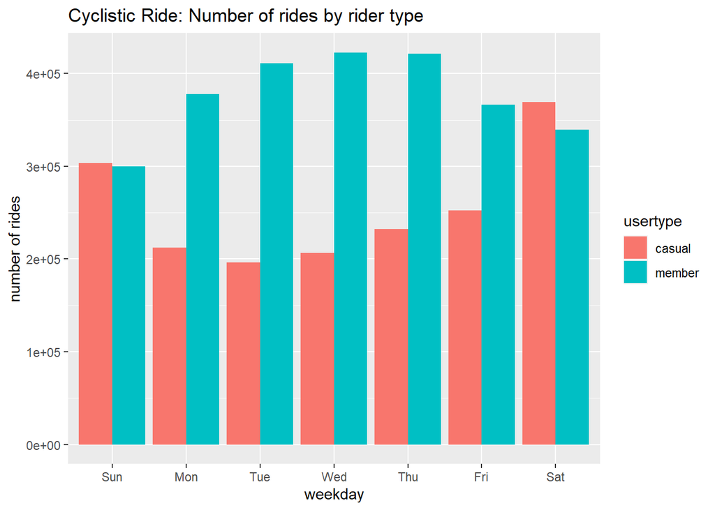

```r
ggplot(data = plot1, aes(x = weekday, y = number_of_rides, fill = usertype)) +
  geom_col(position = "dodge") +
  labs(y = "number of rides", x = "weekday", title= "Cyclistic Ride: Number of rides by rider type")
```

From the plot, it is obvious that casual users tend to ride more on weekends than in weekdays. While member users had slight decrease of number of rides during weekends but not compared to casual riders.

### Let’s create a visualization for average duration

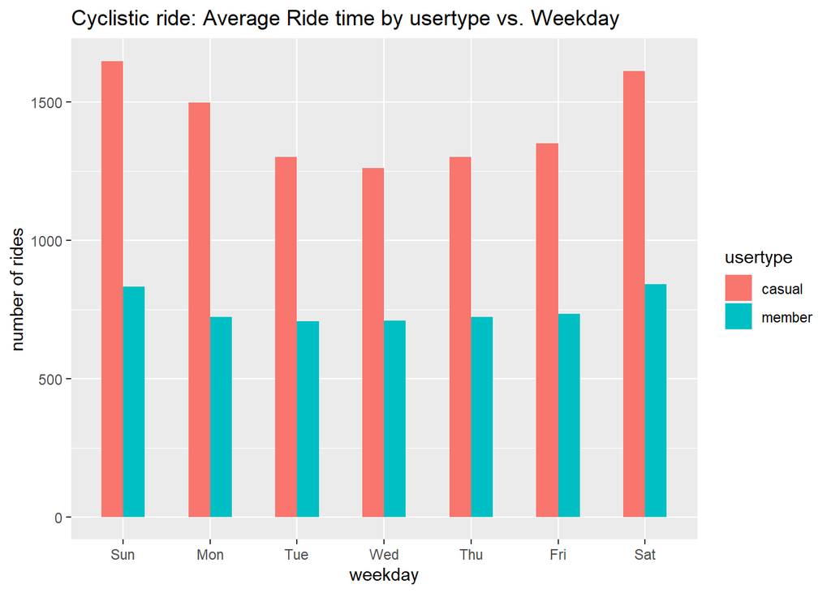

```r
ggplot(plot1, aes(x = weekday, y = average_duration, fill = usertype)) +
  geom_col(position = "dodge", width = 0.5, ) +
  labs(y = "number of rides", x= "weekday", title = "Cyclistic ride: Average Ride time by usertype vs. Weekday")
```

### Visualizing how user type differ depending on total rides taken

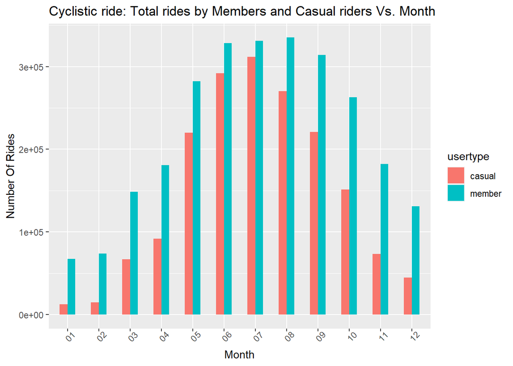

```r
plot2 <- all_trips_v2 %>%
  group_by(usertype, month) %>%
  summarise(number_of_rides = n(), .groups = "drop") %>%
  arrange(usertype, month)

ggplot(plot2, aes(x = month, y = number_of_rides, fill =usertype)) +
  labs(title = "Cyclistic ride: Total rides by Members and Casual riders Vs. Month", x = "Month", y= "Number Of Rides") +
  theme(axis.text.x = element_text(angle = 45)) +
  geom_col(width= 0.5, position = position_dodge(width = 0.5))
```

- The months June, July, August, September are the most busy time of the year for both members and casual riders. Due to winter, there is significant drop in total rides in the months of November, December, January and February for both types of riders.

### Visualize average ride time data by type and month

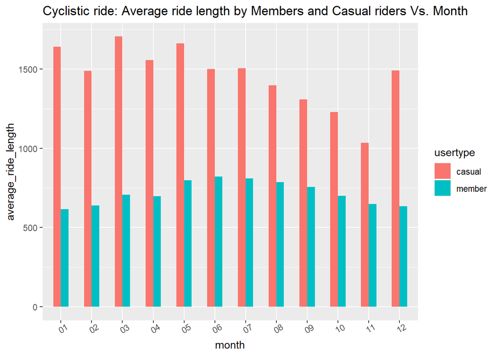

```r
plot3 <- all_trips_v2 %>%
  group_by(usertype, month) %>%
  summarise(average_ride_length = mean(ride_length),.groups="drop")

  ggplot(plot3, aes(x = month, y = average_ride_length, fill = usertype)) +
  geom_col(width = 0.5, position = position_dodge(width = 0.5)) +
  labs(title = "Cyclistic ride: Average ride length by Members and Casual riders Vs. Month") +
  theme(axis.text.x = element_text(angle = 30))
```

### Lets create a visualization for comparison of bike type by user type

[figure not shown]

```r
ggplot(all_trips_v2, aes(x = usertype, y = bikeid , fill = usertype)) +
  geom_col(position = "dodge") +
  labs(title = "Cyclistic ride: Total rides by Members and Casual riders Vs. Month", x = "Usertype", y = "Type Of bike") +
  theme(axis.text.x = element_text(angle = 45)) +
  geom_col(width = 0.5, position = position_dodge(width = 0.5))
```

### Visualization of rides per weekday and user type with type of bike distribution

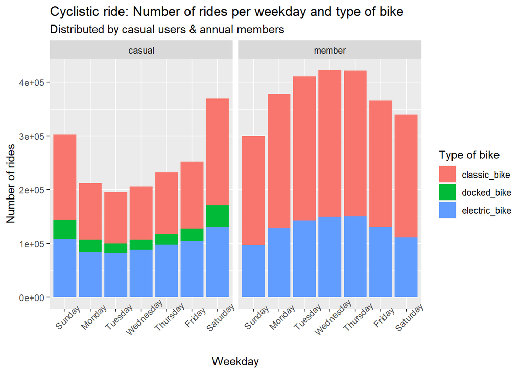

```r
  ggplot(all_trips_v2) +
    geom_bar(mapping = aes(x = day_of_week, fill = bikeid)) +
    facet_wrap(~usertype) +
    theme(axis.text.x = element_text(angle = 45)) +
    labs(title="Cyclistic ride: Number of rides per weekday and type of bike",
         subtitle = "Distributed by casual users & annual members",
         x = "Weekday",
         y = "Number of rides",
         fill = "Type of bike")
```

No clear pattern can be noticed in this plot

### members vs casual riders difference depending on total rides taken

[figure not shown]

```r
plot5 <- all_trips_v2 %>%
    group_by(usertype) %>%
    summarise(ride_count = length(ride_length), ride_percentage = (length(ride_length) / nrow(all_trips_v2)) * 100)
  ggplot(plot5, aes(x = usertype, fill=usertype)) +
    geom_bar() +
    labs(x="Casuals vs Members", y = "Number Of Rides", title = "Cyclistic ride: Casuals vs Members distribution")
```

### Let’s visualize rides per week day and user type

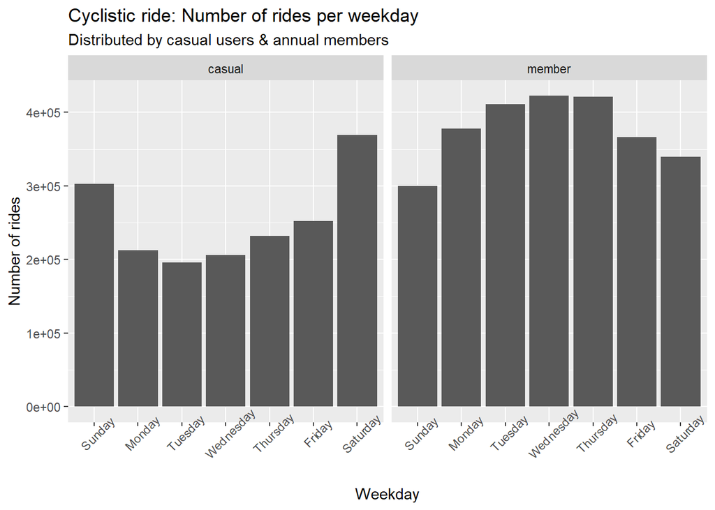

```r
ggplot(all_trips_v2) +
  geom_bar(mapping = aes(x = day_of_week)) +
  facet_wrap(~usertype) +
  theme(axis.text.x = element_text(angle = 45)) +
  labs(title = "Cyclistic ride: Number of rides per weekday",
       subtitle = "Distributed by casual users & annual members",
      x = "Weekday",
      y = "Number of rides")
```